# Exploratory Data Analysis

Group #1: Alex Carriero, Christoph Völtzke, Florian Van Leeuwen, Judith Neve

## Introduction

The focus of this exploratory data analysis is data retrieved from a study on word recall by Dr. Emily Nordmann. The data set contains observations from 31 different participants. Each participant was asked for their age and gender, then to type out as many words as they could think of for each of the following categories: words beginning with the letter “A”, animal names, and swear words. We investigate the data focusing on demographic differences in word recall for each category.

The dataset was downloaded from a public repository on GitHub using the following [link](https://raw.githubusercontent.com/emilynordmann/swearing/master/data.csv). The original data set includes 31 rows (one for each participant) and six columns:

For each prompt, the information provided is a string containing all the words a given participant recalled. In each strings, words are separated by either a space, comma, or `\n`. The data were then tidied and summarized such that the number of words recalled by each participant and for each prompt could be retrieved. Previews of the original data, tidied data and summarized data are displayed below.

#### Original Data

| Timestamp | Age (in whole years) | Gender | Please write as many words as you can beginning with the letter "A". | Please write down as many different types of animal as you can. | Please write down as many swear words as you can. |
| --- | --- | --- | --- | --- | --- |
| 30/08/2019 11:55:54 | NA | Woman | animal alpha alphabet anonymous architect | Cat dog elephant tiger leopard wolf horse mouse rat giraffe zebra mule | Fuck cunt motherfucker bloody shite |
| 30/08/2019 11:58:58 | 30 | Woman | Anniversary, Annual, Analog, Analysis, Apple, Announced, Announcement, Assistant, Assault, Android, | Cat, Dog, Orca, Dolphin, shark, Octopus, Jellyfish, Snake, Turtle, Scorpion, Elephant, Zebra, Giraffe, Monkey, Llama, Polar bear, Grizzly bear, Alpaca, Dinosaur, Meglasaur, Beaver, Sheep, Fox, Panda | Fuck, cunt, Arsehole, Arse, Twat, shit, Shitbag, Bullshit, Moron, Retard |
| 30/08/2019 12:06:09 | 46 | Woman | Angle art aseptic add although also alternate alternatives all adder age are | Lion tiger dog cat iguana snake horse pig cow rabbit fox hound bird leopard rhino elephant crocodile | Fuck shit asshole dickhead cunt |
| 30/08/2019 12:06:10 | 35 | Woman | Angry apathy antique anxious attractive ample aardvark analyst all and any apple arse assess assay antipathy antiquated acknowledgement ape advice | Ape aardvark monkey lemur cat dog hamster degu rabbit guineapig giraffe lion tiger bear antelope ferret llama alpaca camel koala panda newt | Fuck arse bitch dick douche cunt shit bastard motherfucker douchecanoe balls |
| 30/08/2019 12:06:10 | 38 | Woman | And amen also afraid acid acidic acidi arid America amazing arithmetic also any anybody archaic ablaze alright add abstract adverb adjective area are aerial aeroplane aeronautic acrobatic aerobic athl… | Cat dog fox cow sheep lizard bird dolphin horse pony llama beetle butterfly goose donkey deer stallion ladybird fish turtle puffin | Fuck shit bastard bugger arsehole cunt dick dickhead fucking shite shitebag fud |
| 30/08/2019 12:06:10 | 30 | Woman | Apple ant alien alphabet antelope animal arm arse alight align assessment Armageddon arsehole arithmetic and anything any all | Cow dog cat duck goose hamster chicken elephant giraffe rhino antelope ant alligator crocodile moose deer hedgehog whale dolphins fish starfish penguin cheetah monkey human | Shit bitch whore cunt cumbag fuck bullshit asshole motherfucker dammit |
| 30/08/2019 12:06:10 | 35 | Woman | Ass, ablist absolute ape Apple angry anus awful attend and are all about anything | Goose frog cat snake bird horse chicken dog llama goat chicken lion cheetah zebra elephant giraffe vulture Tiger | Cunt bitch dickhead shit fuck ass dick shithead fud asshole fag dyke slut |
| 30/08/2019 12:06:11 | 46 | Woman | Apple\nAeroplane\nAnonymous\nAmazon\nApe\nAnimal\nAnniversary\nAble\nAbility\nAwareness\nActual\nActor\nActress\nAunt\nAmaryllis\nArms\nArmour\nAneroid\nAmerica\n\n\n | Cows\nDogs\nCats\nSheep\nHorses\nCamels\nLions\nBears\nElephants\nSnakes\nFoxes\nPenguins | Fuck\nBugger\nCunt\nBastard\nSlut\n |

#### Tidy Data

| ID | Age | Gender | Prompt | Word |
| --- | --- | --- | --- | --- |
| 1 | NA | Woman | LetterA | animal |
| 1 | NA | Woman | LetterA | alpha |
| 1 | NA | Woman | LetterA | alphabet |
| 1 | NA | Woman | LetterA | anonymous |
| 1 | NA | Woman | LetterA | architect |

#### Summmarised Data

| ID | Prompt | NWords | Age | Gender |
| --- | --- | --- | --- | --- |
| 1 | Animals | 12 | NA | Woman |
| 1 | LetterA | 5 | NA | Woman |
| 1 | Swears | 5 | NA | Woman |
| 2 | Animals | 26 | 30 | Woman |
| 2 | LetterA | 10 | 30 | Woman |

## Descriptive Statistics

Table 1. Number of words recalled by participants for each prompt.

| Prompt | Minimum | Median | Maximum | Nobs |
| --- | --- | --- | --- | --- |
| Animals | 7 | 17 | 27 | 31 |
| LetterA | 4 | 13 | 49 | 31 |
| Swears | 5 | 9 | 16 | 31 |

We generated a further descriptive plot in Figure 2, focusing on the most commonly recalled words, as well as which prompt they were recalled from. In order to leave the plot readable, we decided to focus only on the 20 most commonly recalled words. The frequency computation was done using the data wrangling functions `group_by()` and `summarise()` as this then allowed us to select the most common words. To improve readability, the words were ordered by their frequency using the `arrange()` function and the axes were flipped. The bars were color-coded according to the prompt in which the word was listed. We see most words appearing in this list are animals, and there is one word (“arse”) that appeared often in two different categories.

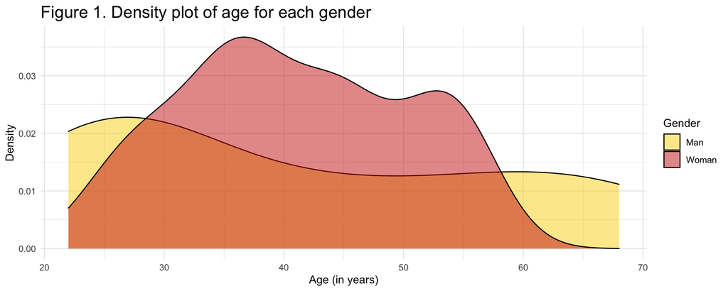

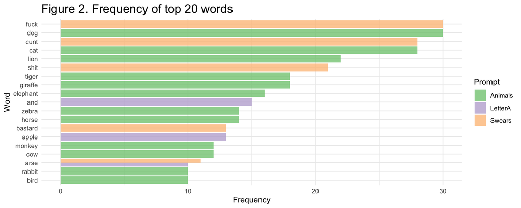

## Exploratory Analysis

To gain further insights from the data, three exploratory research questions were investigated using visualizations; the plots and corresponding interpretations are included below.

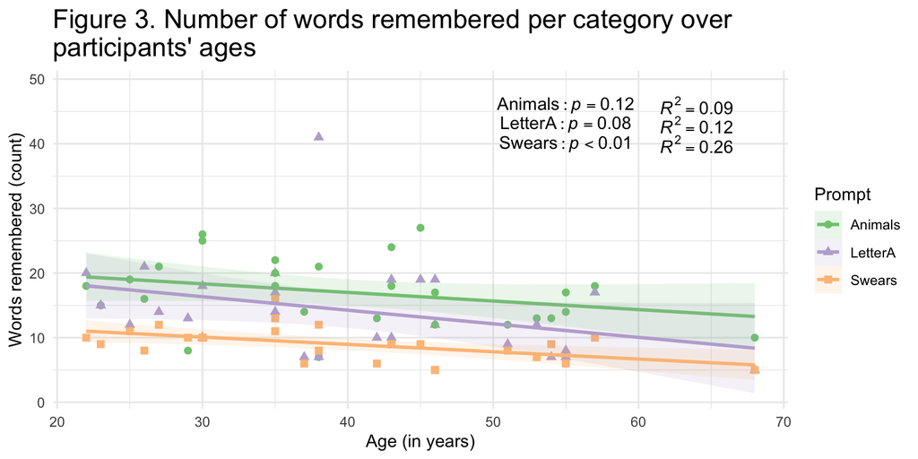

This plot investigates whether there are age differences in the number of words remembered per word category. To answer this research question the participants’ age in years is plotted on the x-axis and the number of words remembered per category is plotted on the y-axis. The word categories are depicted by different shapes and colours in the plot. Further, we included linear regression lines to see if there is a linear relationship between the number of words remembered for each word category and the participants’ age. The results show that all three regression lines indicate decreasing trends, meaning that participants tend to remember fewer words in each category the older they get. Moreover, it seems that there are differences in the number of words remembered between the word categories, and also the slopes vary. Thus, the word category can be seen as a moderator for the effect of the relation between the number of words remembered and participants’ age. However, as indicated by the 95% confidence intervals, these results might not be very reliable as the confidence intervals have wide ranges. In particular, the confidence intervals of the two categories “Animals” and “Words that start with the letter A” mostly overlap and also show wide intervals within the categories, indicating that the negative trend, as well as the difference between the words remembered in these two categories, have to be interpreted with caution. This is also backed up by the linear regression results for the three regression lines as they indicate that only the prediction for swear words is significant ($p < 0.01$). Multiple $R^2$ are also rather low for the regression results of the categories animals ($R^2$ = 0.09) and words that start with the letter A ($R^2$ = 0.12) compared to the results of the swears ($R^2$ = 0.26) category. One possible reason for this high uncertainty might be the low number of participants with $n$ = 27 (since the participants with unknown age were excluded from this part of the analysis). However, the results give a nice indication of the effect of the relationship between age and the number of words remembered as well as the moderating effect of word categories. These results should be still backed up in follow-up research with a higher number of participants and further word categories.

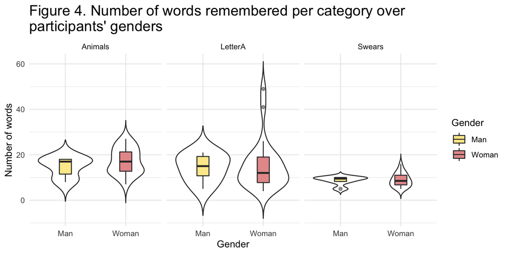

The motivation for this plot is to investigate gender differences in word recall. Gender is mapped to the x-axis, so that the two genders can be easily compared, and number of words recalled is mapped to the y-axis. `facet_wrap()` is then used with respect to the prompt, such that we can explore gender differences in recall for each prompt category. As there was only one participant in the “other” category, they were excluded from this part of the analysis. Two geoms were overlayed to create this plot: `geom_violin()`and `geom_boxplot()` in order to carry information regarding the distributions, with an easy way to process their summary. The boxplot was selected so that key features in the data could be highlighted (i.e., 25th percentile, median and 75th percentile) while the violin plot is used to visualize the entire distribution of the data. From the plot we see that the median number of words recalled is very similar between genders. This appears to hold true for each of the prompt categories. It is however worth noting that only 6 men are included in this data set, while there are 24 women, thus, any conclusions from this exploratory analysis must be mindful of fact that there is much less information provided by men. Considering the gender imbalance, there do not appear to be any major differences in the distributions.

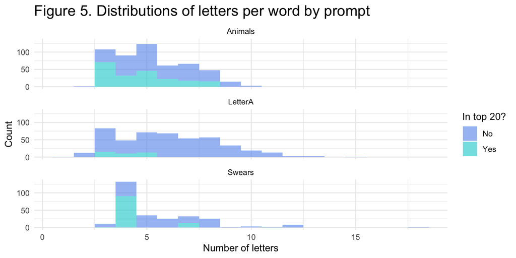

Not every word is equal: a way to distinguish words is to look at the number of letters per word. It is possible that participants focused on shorter words for certain categories (e.g., recalled more short words starting with “A” than long words starting with “A”); alternatively, it is possible that most words within a category are short (e.g., swear words may tend to be shorter). Additionally, we may consider whether the count of the words with a given number of letters was inflated by a high usage of a small subset of words. Figure 5 shows the distributions of the number of letters by prompt. The y-axis is the cumulative count of all words with the same number of letters (i.e., if the same 4-letter word appears twice in the data, it is counted as two. That is, the count is not a count of *unique* words). In order to establish whether the word count is inflated, words are colour-coded according to whether they were among the most common 20 words. It is clear that the count of 4-letter swear words was inflated. Using information from Figure 2, we know this is because of words such as “fuck”, “shit”, and “cunt”. Compared to the other two categories, there are fewer long words. In turn, commonly cited animal names were cited regardless of word length. Finally, the only commonly cited words beginning with “A” are the shorter words, and more short words beginning with “A” were cited than long words beginning with “A”. This suggests that word recall mechanisms differed across categories: when prompted to recall a category based on meaning (animal), word length does not have much effect. When prompted to recall a word from its appearance (beginning with “A”), shorter words are more easily recalled. Finally, swear words tend to be short words with a smaller range of words.  
We now conclude our exploration. Data was tidied in order to focus on individual words; we looked at sample demographics, which words were most commonly given, whether gender or age affected the number of words recalled for each category, and finally, the length of the words recalled. We hope you enjoyed our exploration.